# president_ask

Seo eunyu

2021 4 26

# 0. 패키지 모두 불러오기

```r
library(tidyverse)
library(tidytext)
library(stringr) # 텍스트 전처리시 사용할 string_xxx 함수가 있는 라이브러리
library(readxl) # 엑셀 파일 불러오기 위한 라이브러리
library(scales) # 그래프 축 조정 라이브러리
library(gridExtra) # 워드 클라우드 여러개 불러오기 위한 라이브러리
```

```r
library(ggwordcloud) #ggplot을 이용해서 워드 클라우드를 그리는 라이브러리
library(tidylo) #로그오즈비를 구하기 위해 사용하는 라이브러리
library(ggthemes) # ggplot을 꾸미는 라이브러리
library(KoNLP)# 한국어 형태소 분석 라이브러리
useNIADic() # NIA 사전 사용
```

```
## Backup was just finished!
## 1213109 words dictionary was built.
```

```r
library(showtext) # 구글 텍스트 사용 가능한 라이브러리
font_add_google(name = "Nanum Gothic", family = "nanumgothic") # '나눔고딕' 폰트 적용
font_add_google(name = "Black Han Sans", family = "blackhansans") # '검은고딕' 폰트 적용
showtext_auto() # 추가한 텍스트 사용
```

# 1. 첨부된 대통령 취임사를 사용하여 4명 대통령들의 연설문을 이용하여 다음에 답하시오.

### 단, 단어 길이는 적어도 2이상이어야 함

## (1) 4명의 대통령별로 가장 많이 사용된 각각 상위 단어 10개를 뽑아서 막대그래프를 그리시오. (10)

### 단, 막대 그래프에 단어는 빈도순으로 큰 것부터 작은 순으로 나타내시오.

### 폰트는 나눔고딕을 사용하시오.

### 화면에 출력 창은 한번에 4개의 그래프가 동시에 나타나도록 하시오.

```r
# 원본 파일 불러오기
DF<-read_excel('역대대통령취임사_최근4명.xlsx') # 기본 document에 파일이 들어있어서 파일 경로 쓸 필요 없음

# 토큰화 (띄어쓰기 (word) 단위)
word_space<-DF %>%
  unnest_tokens(input=content,
                output = word,
                token="words")

# 기본적인 전처리
word_space<-word_space %>%
  mutate(word=str_replace_all(word, "[^가-힣]", " "), #힌글 이외에 모두 공백으로 대체. 숫자도 대체함.
         word=str_squish(word))

# 단어 빈도 구하기
frequency<-word_space %>%
  count(President, word) %>%
  filter(str_count(word)>1)

# 대통령별로 사용 빈도가 큰 단어 보기
top10<-frequency %>%
  group_by(President) %>%
  slice_max(n,n=10,with_ties = F)

top10 %>% filter(President=="노무현")
```

```
## # A tibble: 10 x 3
## # Groups:   President [1]
##    President word         n
##    <chr>     <chr>    <int>
##  1 노무현    합니다      34
##  2 노무현    있습니다    22
##  3 노무현    우리는      15
##  4 노무현    국민        11
##  5 노무현    동북아       9
##  6 노무현    것입니다     8
##  7 노무현    우리         8
##  8 노무현    저는         8
##  9 노무현    나갈         7
## 10 노무현    여러분       7
```

```r
top10 %>% filter(President=="이명박")
```

```
## # A tibble: 10 x 3
## # Groups:   President [1]
##    President word         n
##    <chr>     <chr>    <int>
##  1 이명박    합니다      56
##  2 이명박    있습니다    19
##  3 이명박    국민        18
##  4 이명박    것입니다    14
##  5 이명박    나라        11
##  6 이명박    여러분      11
##  7 이명박    함께        10
##  8 이명박    있는         9
##  9 이명박    존경하는     9
## 10 이명박    그리고       8
```

```r
top10 %>% filter(President=="박근혜")
```

```
## # A tibble: 10 x 3
## # Groups:   President [1]
##    President word         n
##    <chr>     <chr>    <int>
##  1 박근혜    국민        26
##  2 박근혜    것입니다    21
##  3 박근혜    새로운      16
##  4 박근혜    우리        15
##  5 박근혜    저는        13
##  6 박근혜    있습니다    12
##  7 박근혜    시대를      10
##  8 박근혜    있도록      10
##  9 박근혜    함께         9
## 10 박근혜    국민이       8
```

```r
top10 %>% filter(President=="문재인")
```

```
## # A tibble: 10 x 3
## # Groups:   President [1]
##    President word             n
##    <chr>     <chr>        <int>
##  1 문재인    대통령이        17
##  2 문재인    되겠습니다      13
##  3 문재인    국민            11
##  4 문재인    새로운           8
##  5 문재인    것입니다         6
##  6 문재인    대통령           5
##  7 문재인    대통령의         5
##  8 문재인    만들겠습니다     5
##  9 문재인    세상을           5
## 10 문재인    위해             5
```

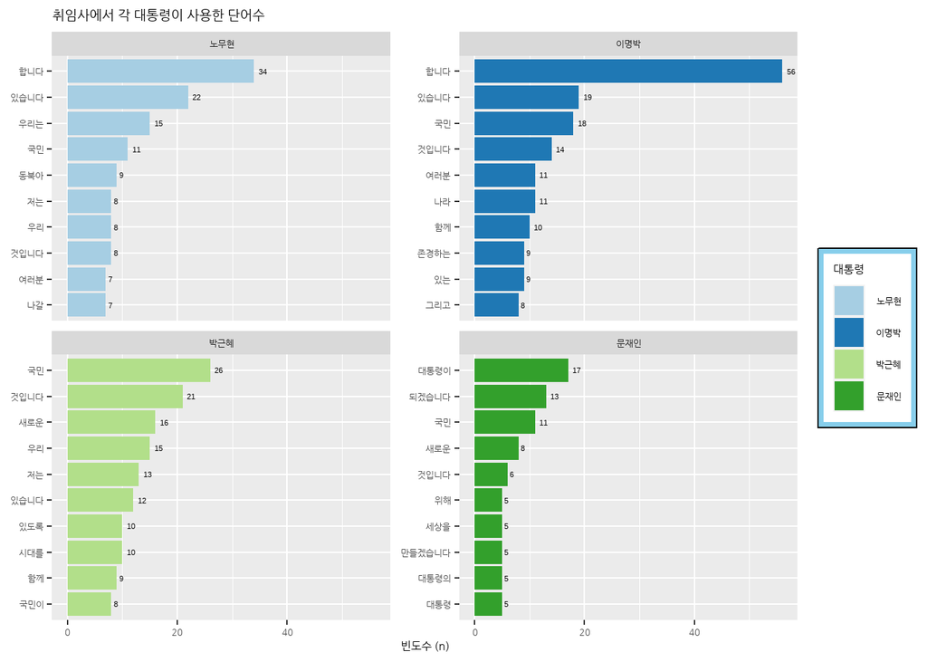

```r
# 그래프 순서 정하기
top10$President <- factor(top10$President,
                          levels = c("노무현", "이명박", "박근혜", "문재인"))

# 막대그래프 그리기
top10 %>%
  ggplot(aes(x=reorder_within(x=word,by=n,within=President),
             y=n,
             fill=President))+
  labs(x = "", y = "빈도수 (n)", title = "취임사에서 각 대통령이 사용한 단어수") +
  scale_fill_brewer(name = '대통령',palette = 'Paired')+
  geom_text(aes(label = n, hjust = -0.5),
            color = "black", size=3)+
  geom_col()+
  coord_flip()+
  facet_wrap(~President,
             scales="free_y")+
  scale_x_reordered()+
  labs(x=NULL)+
  theme(text=element_text(family="nanumgothic", size=12))+
  theme(legend.box.background = element_rect(fill = "skyblue"),
        legend.box.margin = margin(3, 3, 3, 3))
```

## (2) 4명의 대통령별로 가장 많이 사용된 각각 상위 단어를 이용하여 반드시 ggplot을 이용하여 워드클라우드를 그리시오. (10)

### 단, 최소 단어는 3, 최대 단어는 제한 없음, 글자 크기는 최소 3, 최대 20으로 하시오.

### 폰트는 나눔고딕을 사용하시오.

### 글자색은 반드시 화려한 칼라로 나오게 하시오.

### 배경없는 테마를 사용하시오.

### 화면에 출력 창은 한번에 4개의 그래프가 동시에 나타나도록 하시오.

[output not shown]

[output cut: 64 more lines]

[output not shown]

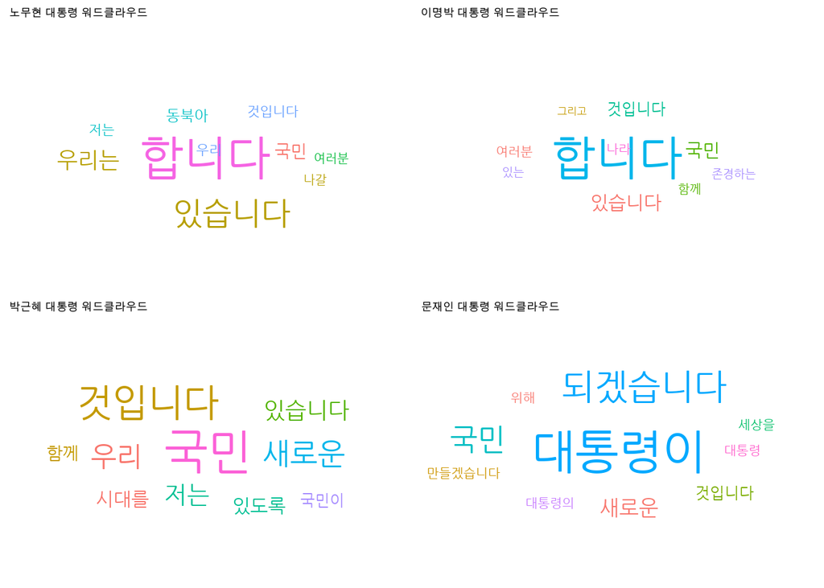

```r
# 대통령별로 가장 많이 사용한 상위 단어
Noe<-top10[top10$President=="노무현",] #top10 %>% filter(President=="노무현")와 동일
Lee<-top10[top10$President=="이명박",]
Park<-top10[top10$President=="박근혜",]
Moon<-top10[top10$President=="문재인",]

# 노무현 대통령 워드 클라우드
word1<-Noe %>%
  ggplot(aes(label = word, size = n,
             color = factor(sample.int(n=10, size=nrow(Noe), replace = TRUE)))) + # 색깔 지정
  geom_text_wordcloud(seed = 1234, family="nanumgothic") + # 폰트 적용
  scale_radius(limits = c(3, NA), # 최소, 최대 단어 빈도
               range = c(3, 20)) + # 최소, 최대 글자 크기
  ggtitle("노무현 대통령 워드클라우드") + # 제목 지정
  theme_minimal() #배경없는 테마 적용

# 이명박 대통령 워드 클라우드
word2<-Lee %>%
  ggplot(aes(label = word, size = n,
             color = factor(sample.int(n=10, size=nrow(Lee), replace = TRUE)))) + # 색깔 지정
  geom_text_wordcloud(seed = 1234,family="nanumgothic") + # 폰트 적용
  scale_radius(limits = c(3, NA), # 최소, 최대 단어 빈도
               range = c(3, 20)) + # 최소, 최대 글자 크기
  ggtitle("이명박 대통령 워드클라우드") + # 제목 지정
  theme_minimal() #배경없는 테마 적용

# 박근혜 대통령 워드 클라우드
word3<-Park %>%
  ggplot(aes(label = word, size = n,
             color = factor(sample.int(n=10, size=nrow(Park), replace = TRUE)))) + # 색깔 지정
  geom_text_wordcloud(seed = 1234, family="nanumgothic") + # 폰트 적용
  scale_radius(limits = c(3, NA), # 최소, 최대 단어 빈도
               range = c(3, 20)) + # 최소, 최대 글자 크기
  ggtitle("박근혜 대통령 워드클라우드") + # 제목 지정
  theme_minimal() #배경없는 테마 적용

# 문재인 대통령 워드 클라우드
word4<-Moon %>%
  ggplot(aes(label = word, size = n,
             color = factor(sample.int(n=10, size=nrow(Moon), replace = TRUE)))) + # 색깔 지정
  geom_text_wordcloud(seed = 1234,family="nanumgothic") + # 폰트 적용
  scale_radius(limits = c(3, NA), # 최소, 최대 단어 빈도
               range = c(3, 20)) + # 최소, 최대 글자 크기
  ggtitle("문재인 대통령 워드클라우드") + # 제목 지정
  theme_minimal() #배경없는 테마 적용

# 각 워드 클라우드 하나로 합치기
grid.arrange(word1,word2,word3,word4,nrow=2, ncol=2)
```

## (3) 4명의 대통령별로가장 많이 사용된 각각 상위 명사 10개를 뽑아서 막대그래프를 그리시오. (10)

### 단, 막대 그래프에 단어는 빈도순으로 큰 것부터 작은 순으로 나타내시오.

### 폰트는 “blackhansans”를 사용하시오.

### 화면에 출력 창은 한번에 4개의 그래프가 동시에 나타나도록 하시오.

```r
# 기본적인 전처리
speeches<-DF %>%
  mutate(content=str_replace_all(content, "[^가-힣]", " "), #힌글 이외에 전처리. 숫자도 없앰
         content=str_squish(content))

# 토큰화 (단어 (형태소 분석) 단위)
speeches<-speeches %>%
  unnest_tokens(input=content,
                output = word,
                token=extractNoun)

# 단어 빈도 구하기
frequency<-speeches %>%
  count(President, word) %>%
  filter(str_count(word)>1)

frequency
```

```
## # A tibble: 1,653 x 3
##    President word       n
##    <chr>     <chr>  <int>
##  1 노무현    가난       1
##  2 노무현    가능       1
##  3 노무현    가일       1
##  4 노무현    가지       1
##  5 노무현    각국       1
##  6 노무현    갈등       1
##  7 노무현    갈림길     1
##  8 노무현    감사       4
##  9 노무현    강구       2
## 10 노무현    강국       1
## # ... with 1,643 more rows
```

```r
# 대통령별로 사용 빈도가 큰 단어 보기
top10<-frequency %>%
  group_by(President) %>%
  slice_max(n,n=10,with_ties = F)

top10 %>% filter(President=="노무현")
```

```
## # A tibble: 10 x 3
## # Groups:   President [1]
##    President word       n
##    <chr>     <chr>  <int>
##  1 노무현    우리      33
##  2 노무현    국민      20
##  3 노무현    동북아    18
##  4 노무현    평화      17
##  5 노무현    여러분    16
##  6 노무현    시대      14
##  7 노무현    세계      13
##  8 노무현    사회      12
##  9 노무현    한반도    12
## 10 노무현    북한       9
```

```r
top10 %>% filter(President=="이명박")
```

```
## # A tibble: 10 x 3
## # Groups:   President [1]
##    President word         n
##    <chr>     <chr>    <int>
##  1 이명박    국민        30
##  2 이명박    우리        26
##  3 이명박    사회        20
##  4 이명박    여러분      18
##  5 이명박    대한민국    17
##  6 이명박    세계        17
##  7 이명박    정부        15
##  8 이명박    문화        12
##  9 이명박    경제        11
## 10 이명박    존경        11
```

```r
top10 %>% filter(President=="박근혜")
```

```
## # A tibble: 10 x 3
## # Groups:   President [1]
##    President word         n
##    <chr>     <chr>    <int>
##  1 박근혜    국민        56
##  2 박근혜    우리        23
##  3 박근혜    시대        22
##  4 박근혜    행복        21
##  5 박근혜    문화        20
##  6 박근혜    여러분      17
##  7 박근혜    대한민국    12
##  8 박근혜    사회        12
##  9 박근혜    국가        10
## 10 박근혜    희망        10
```

```r
top10 %>% filter(President=="문재인")
```

```
## # A tibble: 10 x 3
## # Groups:   President [1]
##    President word         n
##    <chr>     <chr>    <int>
##  1 문재인    대통령      28
##  2 문재인    국민        24
##  3 문재인    대한민국    10
##  4 문재인    나라         9
##  5 문재인    우리         8
##  6 문재인    여러분       7
##  7 문재인    선거         6
##  8 문재인    역사         6
##  9 문재인    정치         6
## 10 문재인    대통령의     5
```

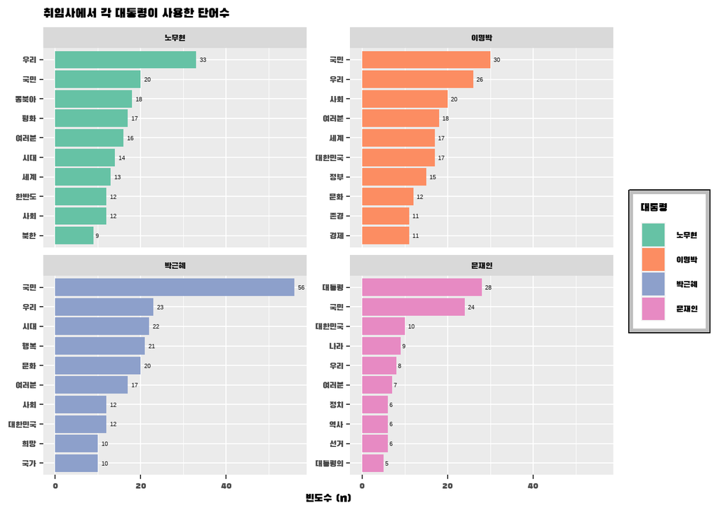

```r
# 그래프 순서 정하기
top10$President <- factor(top10$President,
                          levels = c("노무현", "이명박", "박근혜", "문재인"))

# 막대그래프 그리기
top10 %>%
  ggplot(aes(x=reorder_within(x=word,by=n,within=President),
             y=n,
             fill=President))+
  labs(x = "", y = "빈도수 (n)", title = "취임사에서 각 대통령이 사용한 단어수") +
  scale_fill_brewer(name = '대통령',palette = 'Set2')+
  geom_text(aes(label = n, hjust = -0.5),
            color = "black", size=3)+
  geom_col()+
  coord_flip()+
  facet_wrap(~President,
             scales="free_y")+
  scale_x_reordered()+
  labs(x=NULL)+
  theme(text=element_text(family="blackhansans", size=15))+
    theme(legend.box.background = element_rect(fill = "gray"),
        legend.box.margin = margin(3, 3, 3, 3))
```

## (4) 4명의 대통령별로 가장 많이 사용된 각각 상위 명사를 이용하여 반드시 ggplot을 이용하여 워드클라우드를 그리시오. (10)

### 단, 최소 단어는 3, 최대 단어는 제한 없음, 글자 크기는 최소 3, 최대 20으로 하시오.

### 폰트는 blackhansans"를 사용하시오.

### 글자색은 반드시 화려한 칼라로 나오게 하시오.

### 배경없는 테마를 사용하시오.

[output not shown]

[output cut: 64 more lines]

[output not shown]

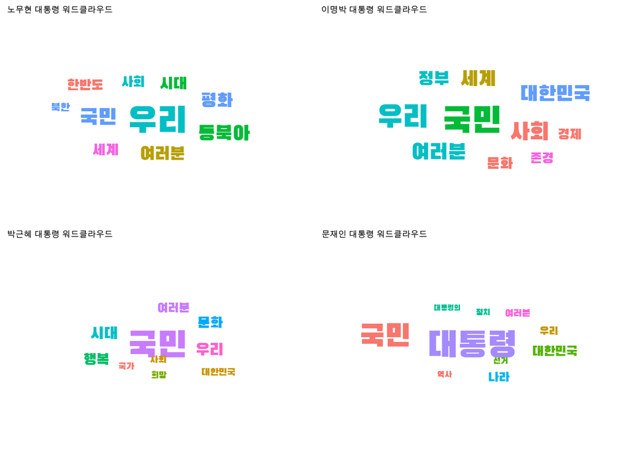

```r
# 대통령별로 가장 많이 사용한 상위 단어
Noe<-top10[top10$President=="노무현",] #top10 %>% filter(President=="노무현")와 동일
Lee<-top10[top10$President=="이명박",]
Park<-top10[top10$President=="박근혜",]
Moon<-top10[top10$President=="문재인",]

# 노무현 대통령 워드 클라우드
word1<-Noe %>%
  ggplot(aes(label = word, size = n,
             color = factor(sample.int(n=10, size=nrow(Noe), replace = TRUE)))) + # 색깔 지정
  geom_text_wordcloud(seed = 1234, family="blackhansans") + # 폰트 적용
  scale_radius(limits = c(3, NA), # 최소, 최대 단어 빈도
               range = c(3, 20)) + # 최소, 최대 글자 크기
  ggtitle("노무현 대통령 워드클라우드") + # 제목 지정
  theme_minimal() #배경없는 테마 적용

# 이명박 대통령 워드 클라우드
word2<-Lee %>%
  ggplot(aes(label = word, size = n,
             color = factor(sample.int(n=10, size=nrow(Lee), replace = TRUE)))) + # 색깔 지정
  geom_text_wordcloud(seed = 1234,family="blackhansans") + # 폰트 적용
  scale_radius(limits = c(3, NA), # 최소, 최대 단어 빈도
               range = c(3, 20)) + # 최소, 최대 글자 크기
  ggtitle("이명박 대통령 워드클라우드") + # 제목 지정
  theme_minimal() #배경없는 테마 적용

# 박근혜 대통령 워드 클라우드
word3<-Park %>%
  ggplot(aes(label = word, size = n,
             color = factor(sample.int(n=10, size=nrow(Park), replace = TRUE)))) + # 색깔 지정
  geom_text_wordcloud(seed = 1234, family="blackhansans") + # 폰트 적용
  scale_radius(limits = c(3, NA), # 최소, 최대 단어 빈도
               range = c(3, 20)) + # 최소, 최대 글자 크기
  ggtitle("박근혜 대통령 워드클라우드") + # 제목 지정
  theme_minimal() #배경없는 테마 적용

# 문재인 대통령 워드 클라우드
word4<-Moon %>%
  ggplot(aes(label = word, size = n,
             color = factor(sample.int(n=10, size=nrow(Moon), replace = TRUE)))) + # 색깔 지정
  geom_text_wordcloud(seed = 1234, family="blackhansans") + # 폰트 적용
  scale_radius(limits = c(3, NA), # 최소, 최대 단어 빈도
               range = c(3, 20)) + # 최소, 최대 글자 크기
  ggtitle("문재인 대통령 워드클라우드") + # 제목 지정
  theme_minimal() #배경없는 테마 적용

# 각 워드 클라우드 하나로 합치기
grid.arrange(word1,word2,word3,word4,nrow=2, ncol=2)
```

# 2. 첨부된 대통령 취임사를 사용하여 4명 대통령들의 연설문을 서로 비교하여 분석하고자 한다. 다음의 질문들에 답하시오. 단, 단어 길이는 적어도 2이상이어야 함

## (1) 4명의 대통령이 중요하게 사용된 명사 단어를 비교하기 위해 각 대통령별 tf-idf가 큰 순서대로 각 10개의 단어들 나타내고 각 대통령들이 무엇을 강조했는지를 설명하시오. (10)

### 단, 대통령이름, 단어(woard), 단어수(n), tf, idf도 같이 출력하시오.

```r
# 기본적인 전처리 (되어 있지만 다시 진행함)
speeches<-DF %>%
  mutate(content=str_replace_all(content, "[^가-힣]", " "), #힌글 이외에 전처리. 숫자도 없앰
         content=str_squish(content))

# 토큰화 (단어 (형태소 분석) 단위) (되어 있지만 다시 진행함)
speeches<-speeches %>%
  unnest_tokens(input=content,
                output = word,
                token=extractNoun)

# 단어 빈도 구하기 (되어 있지만 다시 진행함)
frequency<-speeches %>%
  count(President, word) %>%
  filter(str_count(word)>1)

# tf-idf 구하기
frequency<-frequency %>%
  bind_tf_idf(term=word,
              document=President,
              n=n) %>%
  arrange(-tf_idf)

frequency
```

```
## # A tibble: 1,653 x 6
##    President word         n      tf   idf  tf_idf
##    <chr>     <chr>    <int>   <dbl> <dbl>   <dbl>
##  1 박근혜    행복        21 0.0279  0.693 0.0193
##  2 노무현    동북아      18 0.0231  0.693 0.0160
##  3 박근혜    창조경제     8 0.0106  1.39  0.0147
##  4 노무현    번영         6 0.00770 1.39  0.0107
##  5 문재인    머리         3 0.00723 1.39  0.0100
##  6 문재인    문재인       3 0.00723 1.39  0.0100
##  7 문재인    선거         6 0.0145  0.693 0.0100
##  8 이명박    선진화       8 0.00668 1.39  0.00927
##  9 박근혜    개개인       5 0.00663 1.39  0.00919
## 10 박근혜    경제부흥     5 0.00663 1.39  0.00919
## # ... with 1,643 more rows
```

```r
# 노무현 대통령이 강조한 단어
frequency %>% filter(President=="노무현")
```

```
## # A tibble: 428 x 6
##    President word         n      tf   idf  tf_idf
##    <chr>     <chr>    <int>   <dbl> <dbl>   <dbl>
##  1 노무현    동북아      18 0.0231  0.693 0.0160
##  2 노무현    번영         6 0.00770 1.39  0.0107
##  3 노무현    도약         3 0.00385 1.39  0.00534
##  4 노무현    유럽연합     3 0.00385 1.39  0.00534
##  5 노무현    중앙         3 0.00385 1.39  0.00534
##  6 노무현    타협         3 0.00385 1.39  0.00534
##  7 노무현    세계        13 0.0167  0.288 0.00480
##  8 노무현    극복         5 0.00642 0.693 0.00445
##  9 노무현    사회        12 0.0154  0.288 0.00443
## 10 노무현    강구         2 0.00257 1.39  0.00356
## # ... with 418 more rows
```

```r
# 이명박 대통령이 강조한 단어
frequency %>% filter(President=="이명박")
```

```
## # A tibble: 638 x 6
##    President word       n      tf   idf  tf_idf
##    <chr>     <chr>  <int>   <dbl> <dbl>   <dbl>
##  1 이명박    선진화     8 0.00668 1.39  0.00927
##  2 이명박    변화       6 0.00501 1.39  0.00695
##  3 이명박    실용       5 0.00418 1.39  0.00579
##  4 이명박    안정       5 0.00418 1.39  0.00579
##  5 이명박    이야기     5 0.00418 1.39  0.00579
##  6 이명박    투쟁       5 0.00418 1.39  0.00579
##  7 이명박    기업       9 0.00752 0.693 0.00521
##  8 이명박    사회      20 0.0167  0.288 0.00481
##  9 이명박    개방       4 0.00334 1.39  0.00463
## 10 이명박    선진       4 0.00334 1.39  0.00463
## # ... with 628 more rows
```

```r
# 박근혜 대통령이 강조한 단어
frequency %>% filter(President=="박근혜")
```

```
## # A tibble: 348 x 6
##    President word         n      tf   idf  tf_idf
##    <chr>     <chr>    <int>   <dbl> <dbl>   <dbl>
##  1 박근혜    행복        21 0.0279  0.693 0.0193
##  2 박근혜    창조경제     8 0.0106  1.39  0.0147
##  3 박근혜    개개인       5 0.00663 1.39  0.00919
##  4 박근혜    경제부흥     5 0.00663 1.39  0.00919
##  5 박근혜    희망        10 0.0133  0.693 0.00919
##  6 박근혜    융성         4 0.00531 1.39  0.00735
##  7 박근혜    융합         4 0.00531 1.39  0.00735
##  8 박근혜    국력         3 0.00398 1.39  0.00552
##  9 박근혜    패러다임     3 0.00398 1.39  0.00552
## 10 박근혜    가치         5 0.00663 0.693 0.00460
## # ... with 338 more rows
```

```r
# 문재인 대통령이 강조한 단어
frequency %>% filter(President=="문재인")
```

```
## # A tibble: 239 x 6
##    President word         n      tf   idf  tf_idf
##    <chr>     <chr>    <int>   <dbl> <dbl>   <dbl>
##  1 문재인    머리         3 0.00723 1.39  0.0100
##  2 문재인    문재인       3 0.00723 1.39  0.0100
##  3 문재인    선거         6 0.0145  0.693 0.0100
##  4 문재인    대통령의     5 0.0120  0.693 0.00835
##  5 문재인    세상         5 0.0120  0.693 0.00835
##  6 문재인    광화문       2 0.00482 1.39  0.00668
##  7 문재인    권력         2 0.00482 1.39  0.00668
##  8 문재인    권력기관     2 0.00482 1.39  0.00668
##  9 문재인    빈손         2 0.00482 1.39  0.00668
## 10 문재인    승화         2 0.00482 1.39  0.00668
## # ... with 229 more rows
```

## (2) 앞 (1)에서 나온 결과인 tf-idf를 이용하여 4명의 각 대통령에 대해 크기 순의 tf-idf 막대 그래프를 그리시오. (10)

### 단, 단어 순은 tf-idf가 큰 순서대로 각 10개의 단어들 나타내시오.

### 화면에 출력 창은 한번에 4개의 그래프가 동시에 나타나도록 하시오.

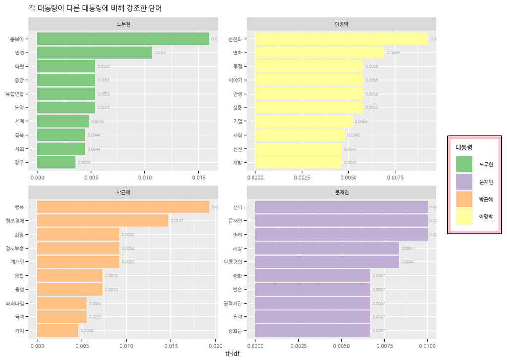

```r
# 주요 단어 추출
top10 <- frequency %>%
  group_by(President) %>%
  slice_max(tf_idf, n = 10, with_ties = F)

# 그래프 순서 정하기
top10$president <- factor(top10$President,
                         levels = c("노무현", "이명박", "박근혜", "문재인"))

# 막대 그래프 만들기
top10 %>%
  ggplot(aes(x = reorder_within(x=word, by=tf_idf, within=President),
             y = tf_idf,
             fill = President)) +
  scale_fill_brewer(name = '대통령',palette = 'Accent')+
  labs(x = "", y = "tf-idf", title = "각 대통령이 다른 대통령에 비해 강조한 단어") +
  geom_text(aes(label = round(tf_idf,4) , hjust = -0.2),
            color = "dark grey", size=3)+
  geom_col() +
  coord_flip() +
  facet_wrap(~ president, scales = "free", ncol = 2) +
  scale_x_reordered() +
  labs(x = NULL) +
  theme(text = element_text(family = "nanumgothic", size=12))+
    theme(legend.box.background = element_rect(fill = "pink"),
        legend.box.margin = margin(3, 3, 3, 3))
```

### 단, 대통령이름, 단어(woard), 단어수(n), tf, idf, tf-idf도 같이 출력하시오.

```r
# 로그 오즈비 구하기
frequency_lo<- frequency %>%
  bind_log_odds(set = President, feature = word, n = n) %>%
  arrange(desc(log_odds_weighted))

frequency_lo
```

```
## # A tibble: 1,653 x 7
##    President word         n      tf   idf  tf_idf log_odds_weighted
##    <chr>     <chr>    <int>   <dbl> <dbl>   <dbl>             <dbl>
##  1 문재인    대통령      28 0.0675  0     0                    5.21
##  2 박근혜    행복        21 0.0279  0.693 0.0193               5.01
##  3 노무현    동북아      18 0.0231  0.693 0.0160               4.49
##  4 문재인    국민        24 0.0578  0     0                    4.38
##  5 박근혜    창조경제     8 0.0106  1.39  0.0147               3.97
##  6 문재인    선거         6 0.0145  0.693 0.0100               3.77
##  7 문재인    대통령의     5 0.0120  0.693 0.00835              3.44
##  8 문재인    세상         5 0.0120  0.693 0.00835              3.44
##  9 노무현    번영         6 0.00770 1.39  0.0107               3.37
## 10 박근혜    희망        10 0.0133  0.693 0.00919              3.33
## # ... with 1,643 more rows
```

```r
# 노무현 대통령의 상대적인 로그오즈 (상대적으로 많이 쓰이는 단어)
frequency_lo %>% filter(President=="노무현")
```

```
## # A tibble: 428 x 7
##    President word         n      tf   idf  tf_idf log_odds_weighted
##    <chr>     <chr>    <int>   <dbl> <dbl>   <dbl>             <dbl>
##  1 노무현    동북아      18 0.0231  0.693 0.0160               4.49
##  2 노무현    번영         6 0.00770 1.39  0.0107               3.37
##  3 노무현    도약         3 0.00385 1.39  0.00534              2.38
##  4 노무현    유럽연합     3 0.00385 1.39  0.00534              2.38
##  5 노무현    중앙         3 0.00385 1.39  0.00534              2.38
##  6 노무현    타협         3 0.00385 1.39  0.00534              2.38
##  7 노무현    극복         5 0.00642 0.693 0.00445              2.25
##  8 노무현    개혁         4 0.00513 0.693 0.00356              2.04
##  9 노무현    과제         4 0.00513 0.693 0.00356              2.04
## 10 노무현    원칙         4 0.00513 0.693 0.00356              2.04
## # ... with 418 more rows
```

```r
# 이명박 대통령의 상대적인 로그오즈 (상대적으로 많이 쓰이는 단어)
frequency_lo %>% filter(President=="이명박")
```

```
## # A tibble: 638 x 7
##    President word       n      tf   idf  tf_idf log_odds_weighted
##    <chr>     <chr>  <int>   <dbl> <dbl>   <dbl>             <dbl>
##  1 이명박    선진화     8 0.00668  1.39 0.00927              3.10
##  2 이명박    변화       6 0.00501  1.39 0.00695              2.69
##  3 이명박    실용       5 0.00418  1.39 0.00579              2.45
##  4 이명박    안정       5 0.00418  1.39 0.00579              2.45
##  5 이명박    이야기     5 0.00418  1.39 0.00579              2.45
##  6 이명박    투쟁       5 0.00418  1.39 0.00579              2.45
##  7 이명박    개방       4 0.00334  1.39 0.00463              2.19
##  8 이명박    선진       4 0.00334  1.39 0.00463              2.19
##  9 이명박    전통       4 0.00334  1.39 0.00463              2.19
## 10 이명박    통일       4 0.00334  1.39 0.00463              2.19
## # ... with 628 more rows
```

```r
# 박근혜 대통령의 상대적인 로그오즈 (상대적으로 많이 쓰이는 단어)
frequency_lo %>% filter(President=="박근혜")
```

```
## # A tibble: 348 x 7
##    President word         n      tf   idf  tf_idf log_odds_weighted
##    <chr>     <chr>    <int>   <dbl> <dbl>   <dbl>             <dbl>
##  1 박근혜    행복        21 0.0279  0.693 0.0193               5.01
##  2 박근혜    창조경제     8 0.0106  1.39  0.0147               3.97
##  3 박근혜    희망        10 0.0133  0.693 0.00919              3.33
##  4 박근혜    개개인       5 0.00663 1.39  0.00919              3.13
##  5 박근혜    경제부흥     5 0.00663 1.39  0.00919              3.13
##  6 박근혜    융성         4 0.00531 1.39  0.00735              2.80
##  7 박근혜    융합         4 0.00531 1.39  0.00735              2.80
##  8 박근혜    국력         3 0.00398 1.39  0.00552              2.43
##  9 박근혜    패러다임     3 0.00398 1.39  0.00552              2.43
## 10 박근혜    개인         5 0.00663 0.693 0.00460              2.38
## # ... with 338 more rows
```

```r
# 문재인 대통령의 상대적인 로그오즈 (상대적으로 많이 쓰이는 단어)
frequency_lo %>% filter(President=="문재인")
```

```
## # A tibble: 239 x 7
##    President word         n      tf   idf  tf_idf log_odds_weighted
##    <chr>     <chr>    <int>   <dbl> <dbl>   <dbl>             <dbl>
##  1 문재인    대통령      28 0.0675  0     0                    5.21
##  2 문재인    국민        24 0.0578  0     0                    4.38
##  3 문재인    선거         6 0.0145  0.693 0.0100               3.77
##  4 문재인    대통령의     5 0.0120  0.693 0.00835              3.44
##  5 문재인    세상         5 0.0120  0.693 0.00835              3.44
##  6 문재인    머리         3 0.00723 1.39  0.0100               3.13
##  7 문재인    문재인       3 0.00723 1.39  0.0100               3.13
##  8 문재인    이번         4 0.00964 0.693 0.00668              3.07
##  9 문재인    정치         6 0.0145  0.288 0.00416              2.99
## 10 문재인    동북아       1 0.00241 0.693 0.00167              2.93
## # ... with 229 more rows
```

### 단, 단어 순은 가중로그오즈비가 큰 순서대로 각 10개의 단어들 나타내시오.

### 화면에 출력 창은 한번에 4개의 그래프가 동시에 나타나도록 하시오.

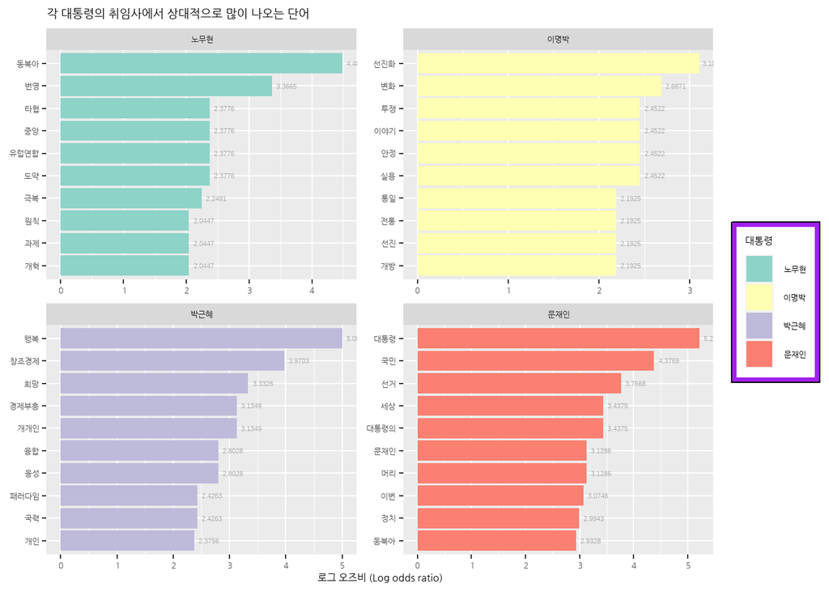

```r
# 주요 단어 추출
top10_lo <- frequency_lo %>%
  group_by(President) %>%
  slice_max(log_odds_weighted, n = 10, with_ties = F)

# 그래프 순서 정하기
top10_lo$President <- factor(top10_lo$President,
                                 levels = c("노무현", "이명박", "박근혜", "문재인"))

# 막대 그래프 만들기
top10_lo %>%
  ggplot(aes(x = reorder_within(x=word, by=log_odds_weighted, within=President),
             y = log_odds_weighted,
             fill = President)) +
  scale_fill_brewer(name = '대통령',palette = 'Set3')+
  labs(x = "", y = "로그 오즈비 (Log odds ratio)", title = "각 대통령의 취임사에서 상대적으로 많이 나오는 단어") +
  geom_text(aes(label = round(log_odds_weighted,4) , hjust = -0.2),
            color = "dark grey", size=3) +
  geom_col() +
  coord_flip() +
  facet_wrap(~ President, scales = "free", ncol = 2) +
  scale_x_reordered() +
  labs(x = NULL) +
  theme(text = element_text(family = "nanumgothic", size=12))+
  theme(legend.box.background = element_rect(fill = "purple"),
        legend.box.margin = margin(3, 3, 3, 3))
```

## (5) 노무현 대통령과 이명박 대통령의 각 취임사의 중요단어를 비교하고자 한다. 노무현 대통령과 이명박 대통령의 취임사에서 각각 사용된 단어들의 RR(relative risk 또는 상대 효율)과 로그RR(log relative risk)를 중요한 순서대로 추출하여 두 대통령별 각각 10개씩 출력하시오. (10)

### 단, RR은 노무현대통령을 분자로 이명박대통령은 분모로 할 것.

```r
# 단어 빈도 구하기
frequency<-speeches %>%
  count(President, word) %>%
  filter(str_count(word)>1)

# 노무현 대통령 취임사에서 비중이 높은 단어 알아보기
frequency_wide <- frequency %>%
  pivot_wider(names_from = President,
              values_from = n,
              values_fill = list(n = 0)) %>%
  mutate(ratio_noe = ((노무현+ 1)/(sum(노무현 + 1))), # 노무현 대통령 취임사에서의 단어 비중
         ratio_lee = ((이명박 + 1)/(sum(이명박 + 1))), # 이명박 대통령 취임사에서의 단어 비중
         rr = ratio_noe/ratio_lee, # 상대위험도(RR) 변수 추가
         log_rr = log(((노무현 + 1)/(sum(노무현 + 1)))/
                        ((이명박 + 1)/(sum(이명박 + 1))))) %>%
  dplyr::select(-문재인,-박근혜) %>%
  arrange(-log_rr)

frequency_wide
```

```
## # A tibble: 1,170 x 7
##    word     노무현 이명박 ratio_noe ratio_lee    rr log_rr
##    <chr>     <int>  <int>     <dbl>     <dbl> <dbl>  <dbl>
##  1 동북아       18      0   0.00975  0.000422 23.1    3.14
##  2 번영          6      0   0.00359  0.000422  8.50   2.14
##  3 한반도       12      1   0.00667  0.000845  7.89   2.07
##  4 극복          5      0   0.00308  0.000422  7.29   1.99
##  5 개혁          4      0   0.00257  0.000422  6.07   1.80
##  6 도전          4      0   0.00257  0.000422  6.07   1.80
##  7 도약          3      0   0.00205  0.000422  4.86   1.58
##  8 동맹          3      0   0.00205  0.000422  4.86   1.58
##  9 안전          3      0   0.00205  0.000422  4.86   1.58
## 10 유럽연합      3      0   0.00205  0.000422  4.86   1.58
## # ... with 1,160 more rows
```

```r
# 이명박 대통령 취임사에서 비중이 높은 단어 알아보기
frequency_wide %>%
  arrange(log_rr)
```

```
## # A tibble: 1,170 x 7
##    word     노무현 이명박 ratio_noe ratio_lee    rr log_rr
##    <chr>     <int>  <int>     <dbl>     <dbl> <dbl>  <dbl>
##  1 선진화        0      8  0.000513   0.00380 0.135  -2.00
##  2 일자리        0      6  0.000513   0.00296 0.173  -1.75
##  3 생활          0      6  0.000513   0.00296 0.173  -1.75
##  4 변화          0      6  0.000513   0.00296 0.173  -1.75
##  5 대한민국      2     17  0.00154    0.00760 0.202  -1.60
##  6 모두          0      5  0.000513   0.00253 0.202  -1.60
##  7 실용          0      5  0.000513   0.00253 0.202  -1.60
##  8 안정          0      5  0.000513   0.00253 0.202  -1.60
##  9 이야기        0      5  0.000513   0.00253 0.202  -1.60
## 10 투쟁          0      5  0.000513   0.00253 0.202  -1.60
## # ... with 1,160 more rows
```

```r
# 로그 RR을 이용해 각 취임사에서 상대적으로 중요한 단어를 각각 10개씩 추출
top10 <- frequency_wide %>%
  group_by(President = ifelse(log_rr > 0, "노무현", "이명박")) %>%
  slice_max(abs(log_rr), n=10, with_ties=FALSE) %>%
  arrange(-log_rr) %>%
  dplyr::select(word, 노무현, 이명박, log_rr, President) %>%
  print(n=Inf)
```

```
## # A tibble: 20 x 5
## # Groups:   President [2]
##    word     노무현 이명박 log_rr President
##    <chr>     <int>  <int>  <dbl> <chr>
##  1 동북아       18      0   3.14 노무현
##  2 번영          6      0   2.14 노무현
##  3 한반도       12      1   2.07 노무현
##  4 극복          5      0   1.99 노무현
##  5 개혁          4      0   1.80 노무현
##  6 도전          4      0   1.80 노무현
##  7 도약          3      0   1.58 노무현
##  8 동맹          3      0   1.58 노무현
##  9 안전          3      0   1.58 노무현
## 10 유럽연합      3      0   1.58 노무현
## 11 대한민국      2     17  -1.60 이명박
## 12 모두          0      5  -1.60 이명박
## 13 실용          0      5  -1.60 이명박
## 14 안정          0      5  -1.60 이명박
## 15 이야기        0      5  -1.60 이명박
## 16 투쟁          0      5  -1.60 이명박
## 17 일자리        0      6  -1.75 이명박
## 18 생활          0      6  -1.75 이명박
## 19 변화          0      6  -1.75 이명박
## 20 선진화        0      8  -2.00 이명박
```

## (6) (5)에서 나온 결과를 이용하여 로그RR(log relative risk)를 가지고 왼쪽(음수)는 이명박 대통령, 오른쪽(양수)은 노무현 대통령을 나타내는 막대 그래프를 그리시오.

### 단, 단어 순은 로그RR 큰 순서대로 왼쪽과 오른쪽 각 10개의 단어들 나타내시오. (10)

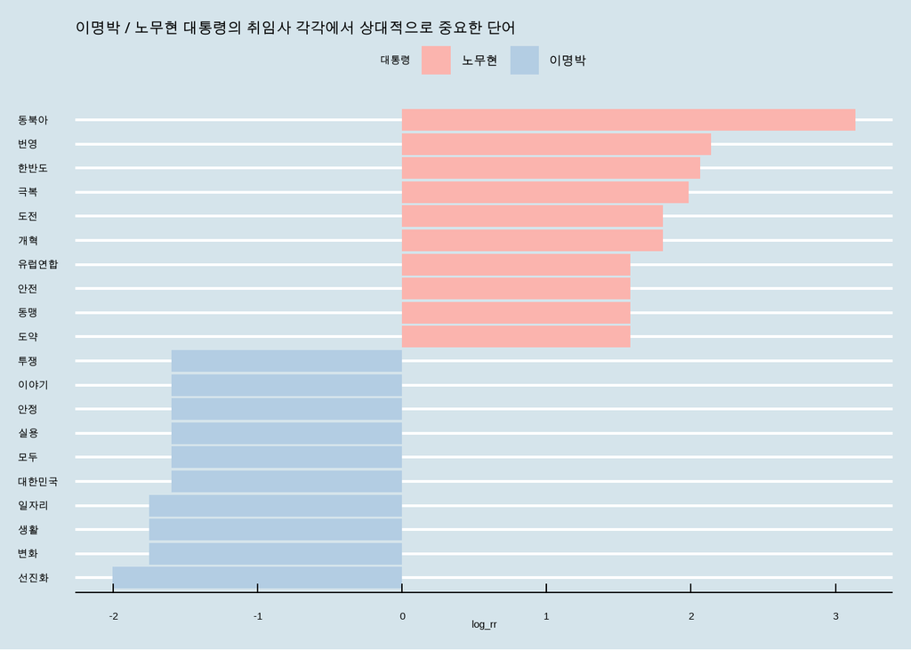

```r
# 막대 그래프 그리기
top10 %>%
  ggplot(aes(x = reorder(word, log_rr),
             y = log_rr,
             fill = President)) +
  scale_fill_brewer(name = '대통령', palette = 'Pastel1') +
  labs(title = "이명박 / 노무현 대통령의 취임사 각각에서 상대적으로 중요한 단어") +
  geom_col() +
  coord_flip() +
  labs(x = NULL) +
  theme(text = element_text(family = "nanumgothic")) +
  scale_color_economist() + theme_economist()
```